# Importing Libraries

# Feature plot to visualize expression of gene of interest in different clusters

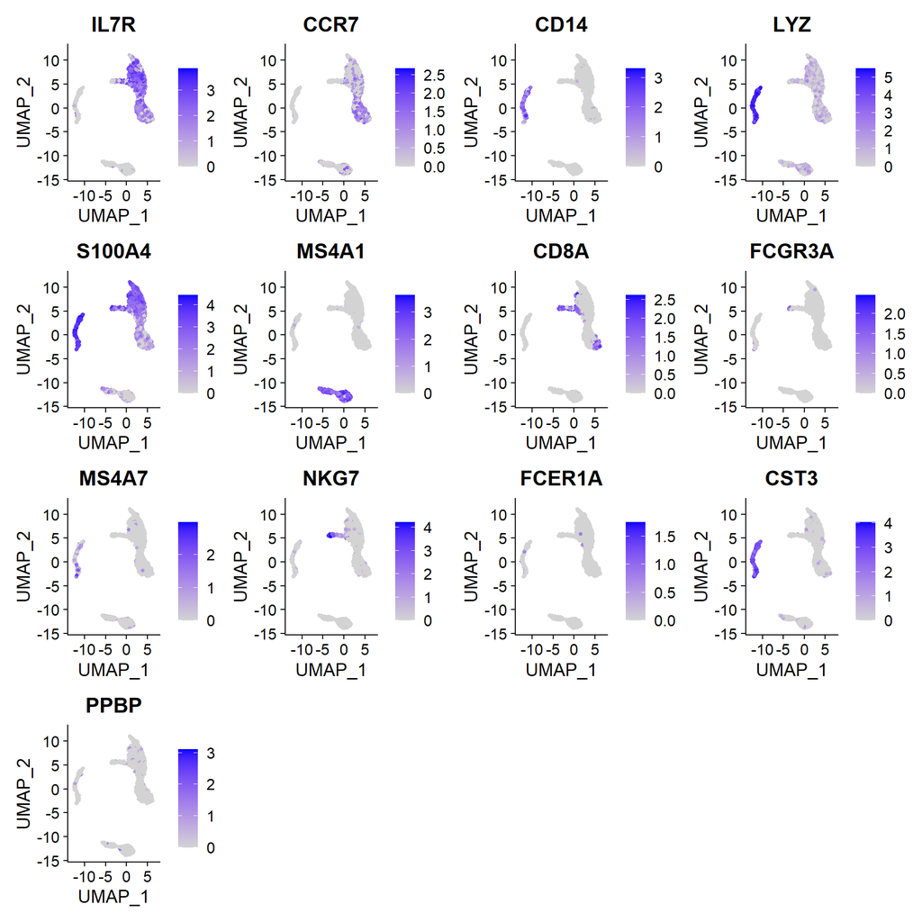

```r
FeaturePlot(pbmc, features = c("IL7R", "CCR7", "CD14", "LYZ", "S100A4", "MS4A1", "CD8A", "FCGR3A", "MS4A7", "NKG7", "FCER1A", "CST3", "PPBP"))
```

# QC for clustering

Since cells can be clustered on the basis of different biological or technical artifacts such as cell cycle states or sequencing bias for different genes. Here we are counting the normal of RNA in different clusters to see if this is a factor affecting the clustering here. However, we can see the number of RNA is almost uniformly distributed among all clusters.

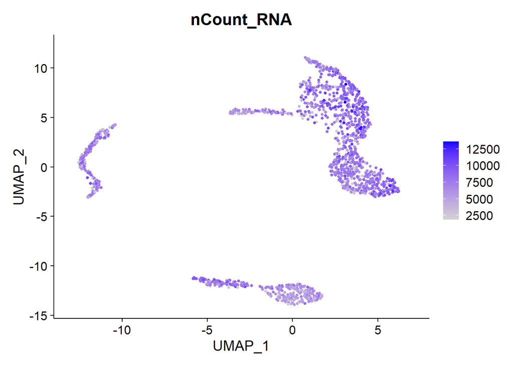

```r
FeaturePlot(pbmc, features = "nCount_RNA")
```

# Visulazing the clusters using ggPlot.

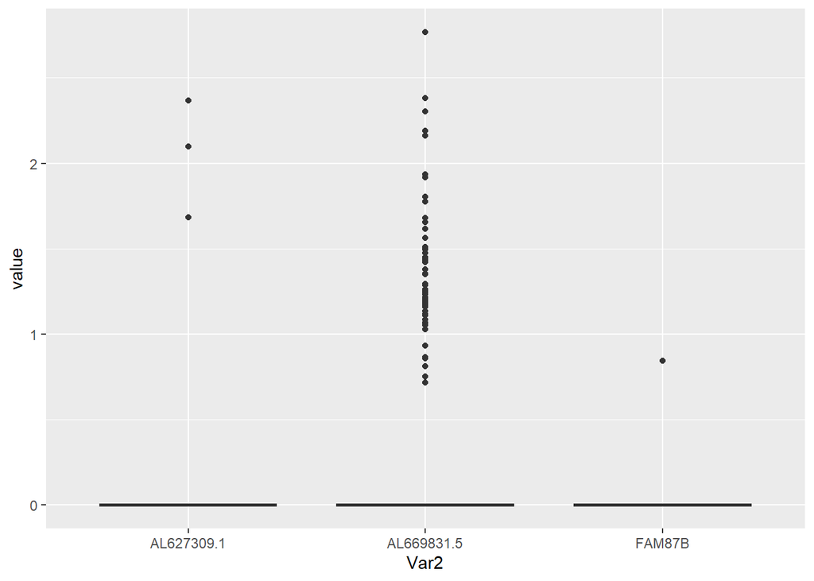

```r
test_gene_expression <- pbmc@assays$RNA@data[c(1,2,3),]
test_gene_expression <- as.data.frame(test_gene_expression)
# swap columns and rows
test_gene_expression <- t(test_gene_expression)
library(reshape2)
# melt for ggplotinput
test_gene_expression<-melt(test_gene_expression, ID = 0)
# plot
ggplot(data = test_gene_expression, mapping = aes(x = Var2, y = value)) +geom_boxplot()
```

The x-axis represents the three genes (Var2), and the y-axis represents the expression level (value).

# Extracting cell ‘locations’ on the UMAP from the Seurat object and creating a ggplot of cells, colored by their cluster identity.

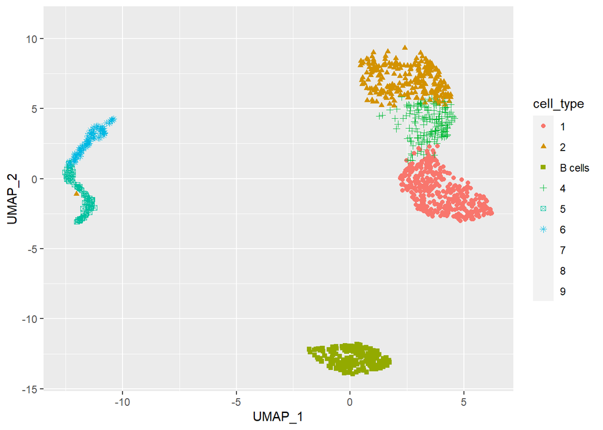

```r
pbmc_umap<-as.data.frame(pbmc[["umap"]]@cell.embeddings)
pbmc_umap$barcode<-rownames(pbmc_umap)
# extract cluster numbers/names from Seurat object
pbmc_clusters<-as.data.frame(pbmc@active.ident)
pbmc_clusters$barcode<-rownames(pbmc_clusters)
# merge cluster names/numbers and cell ‘locations’
pbmc_umap_barcodes<-merge(pbmc_clusters, pbmc_umap, by = "barcode")
# rename columns$
colnames(pbmc_umap_barcodes) <-c("barcode", "cell_type", "UMAP_1","UMAP_2")
umap_plot<-ggplot(pbmc_umap_barcodes, mapping = aes(x = UMAP_1, y = UMAP_2,color= cell_type, shape = cell_type, fill = cell_type)) +geom_point()
umap_plot
```

# Counting the number of cells in each cluster

```r
table(pbmc@meta.data$seurat_clusters)
```

```
##
##   0   1   2   3   4   5   6   7   8
## 383 242 177 168 101  97  93  87  76
```

```r
pbmc$broad.cell.types <- Idents(pbmc)
```

# Visualizing the number of cells in each cluster

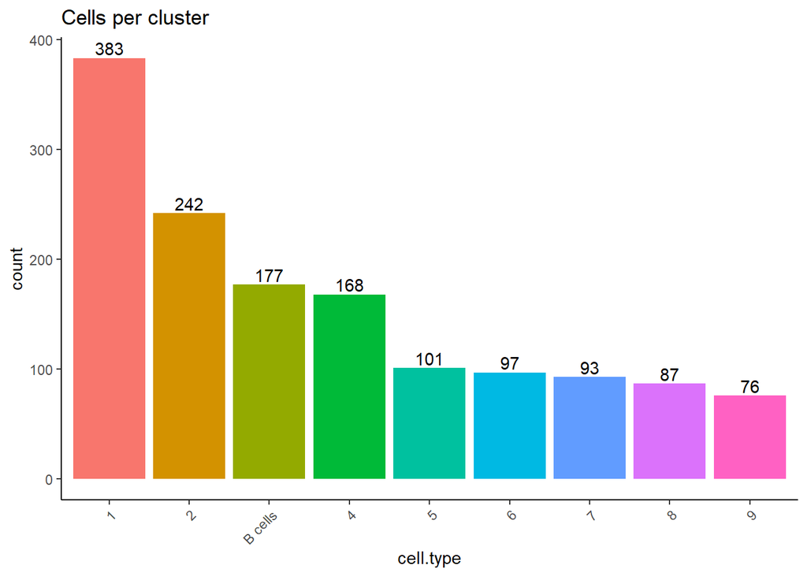

```r
data <- as.data.frame(table(pbmc$broad.cell.types))
colnames(data) <- c("cell.type", "count")

ncells <- ggplot(data, aes(x=cell.type, y=count, fill=cell.type)) +
  geom_col() +
  theme_classic() +
  geom_text(aes(label=count),
            position=position_dodge(width=0.9),
            vjust=-0.25) +
  ggtitle("Cells per cluster") +
  theme(legend.position = "none") +
  theme(axis.text.x = element_text(angle = 45, hjust = 1))
ncells
```

```r
saveRDS(pbmc, file = "C:/Users/bbara/Desktop/pbmc_tutorial.rds")
```